# 20230127_Yulu

```python
# !pip install matplotlib --upgrade
```

**Note:**

- Upgrade the matplotlib version form 3.2.2 to 3.5.3
  - Use command

    ```
    !pip install matplotlib --upgrade
    ```

- Restart the session

# Define Problem Statement and perform Exploratory Data Analysis

**About Yulu**

Yulu is India’s leading micro-mobility service provider, which offers unique vehicles for the daily commute. Starting off as a mission to eliminate traffic congestion in India, Yulu provides the safest commute solution through a user-friendly mobile app to enable shared, solo and sustainable commuting.

Yulu zones are located at all the appropriate locations (including metro stations, bus stands, office spaces, residential areas, corporate offices, etc) to make those first and last-miles smooth, affordable, and convenient!

**Business Problem**

Yulu has recently suffered considerable dips in their revenues. They have contracted a consulting company to understand the factors on which the demand for these shared electric cycles depends. Specifically, they want to understand the factors affecting the demand for these shared electric cycles in the American market.

**Analysis Approach and Assumptions**

Since the significance level to test the hypothesis is not mentioned, we will consider 0.05 as a thresold as it is most comonly used.

**We will carry out the following steps:**

- Observe shape of the data, the data types of all attributes
- Data cleansing, missing value detection, outlier checking, statistical summarization
- Conversion of data types
- Non-graphical analysis: value counts and unique attributes
- Visual analysis - univariate and bivariate analysis using distplot, countplot, histogram, boxplot
- Understanding patterns and preferences
- Setup hypothesis to test dependance of variables: 2 sample t-test, ANOVA test, chi-squared test

## Download the dataset and observe a subset of the data

**Importing Required Libraries**

```python
# !pip install matplotlib==3.6.2
import numpy as np
import pandas as pd
import matplotlib
import matplotlib.pyplot as plt
from matplotlib.ticker import (MultipleLocator, AutoMinorLocator)
import seaborn as sns
import textwrap
import math
from scipy.stats import norm
from scipy import stats
```

```python
# !gdown https://drive.google.com/file/d/1o94fXnmvrx6jRgI6S-SeZ3tfnKjCDY0i/view?usp=sharing -O yulu_data.csv
```

```python
df = pd.read_csv('bike_sharing.csv')
df.head()
```

|  | datetime | season | holiday | workingday | weather | temp | atemp | humidity | windspeed | casual | registered | count |
| --- | --- | --- | --- | --- | --- | --- | --- | --- | --- | --- | --- | --- |
| 0 | 2011-01-01 00:00:00 | 1 | 0 | 0 | 1 | 9.84 | 14.395 | 81 | 0.0 | 3 | 13 | 16 |
| 1 | 2011-01-01 01:00:00 | 1 | 0 | 0 | 1 | 9.02 | 13.635 | 80 | 0.0 | 8 | 32 | 40 |
| 2 | 2011-01-01 02:00:00 | 1 | 0 | 0 | 1 | 9.02 | 13.635 | 80 | 0.0 | 5 | 27 | 32 |
| 3 | 2011-01-01 03:00:00 | 1 | 0 | 0 | 1 | 9.84 | 14.395 | 75 | 0.0 | 3 | 10 | 13 |
| 4 | 2011-01-01 04:00:00 | 1 | 0 | 0 | 1 | 9.84 | 14.395 | 75 | 0.0 | 0 | 1 | 1 |

Custom function to get Discriptive Summary of the Dataset

```python
def get_df_summary(df_, print_summary=True, properties_as_columns=True):
  # Shape and memory usage of DataFrame
  print(f'RangeIndex: {df_.shape[0]} entries; Data columns (total {df_.shape[1]} columns)')
  memory_used = df_.memory_usage().sum()/1024
  if memory_used > 1024*1024:
    memory_used =  f'{round(memory_used/1024/1024, 1)}+ GB'
  elif memory_used > 1024:
    memory_used =  f'{round(memory_used/1024, 1)}+ MB'
  else:
    memory_used =  f'{round(memory_used, 1)}+ KB'
  print(f'memory usage: {memory_used}\n')

  # Create an empty df with column names from original df
  df2 = pd.DataFrame(columns=[None]+df_.columns.to_list())

  # Add dtype
  property_ = ['dtype']
  for clm in df_.columns:
    property_.append(df_[clm].dtype)
  df2 = df2.append(pd.DataFrame([property_], columns=df2.columns))

  # Add Missing Values Counts
  property_ = ['Missing Counts']
  for clm in df_.columns:
    property_.append(df_[clm].isna().sum())
  df2 = df2.append(pd.DataFrame([property_], columns=df2.columns))

  # Add nUniques
  property_ = ['nUniques']
  for clm in df_.columns:
    property_.append(df_[clm].nunique())
  df2 = df2.append(pd.DataFrame([property_], columns=df2.columns))

  # Add unique values
  property_ = ['Top 10 Unique Values']
  for clm in df_.columns:
    df1 = df_[clm].value_counts().reset_index()
    df1['margin'] = df1[clm]*100/ df1[clm].sum()
    property_.append(', '.join([i for i in df1.apply(lambda x:f"{x['index']} ({math.floor(x['margin'])}%)", axis=1).iloc[:10]]))
  df2 = df2.append(pd.DataFrame([property_], columns=df2.columns))

  # Getting Numeric Variables Statistics
  df4 = pd.DataFrame(columns=df_.columns.to_list())
  df4 = df4.append(df_.describe()).drop('count').rename({
      '25%': 'Q1',
      '50%': 'Median',
      '75%': 'Q3'
  }).reset_index().set_index('index').round(1)
  df4 = df4.T
  df4['LW (1.5)'] = df4.apply(lambda x: max(x['min'], x['Q1'] - 1.5*(x['Q3']-x['Q1'])), axis=1)
  df4['UW (1.5)'] = df4.apply(lambda x: min(x['max'], x['Q3'] + 1.5*(x['Q3']-x['Q1'])), axis=1)

  df4['mean-3*std'] = df4.apply(lambda x: max(x['min'], x['mean'] - 3*x['std']), axis=1)
  df4['mean+3*std'] = df4.apply(lambda x: min(x['max'], x['mean'] + 3*x['std']), axis=1)

  lst_IQR_Outlier = []
  lst_std_Outlier = []
  for clm in df4.index:
    if clm in df_.describe().columns:
      iqr_outlier_count = df_.loc[(df_[clm]<df4.loc[clm,'LW (1.5)']) | (df_[clm]>df4.loc[clm,'UW (1.5)'])].shape[0]
      iqr_outlier_pct = f'({round(iqr_outlier_count * 100.0 / df_.__len__(), 1)}%)' if iqr_outlier_count != 0 else ''

      std_outlier_count = df_.loc[(df_[clm]<df4.loc[clm,'mean-3*std']) | (df_[clm]>df4.loc[clm,'mean+3*std'])].shape[0]
      std_outlier_pct = f'({round(std_outlier_count * 100.0 / df_.__len__(), 1)}%)' if std_outlier_count != 0 else ''

      lst_IQR_Outlier.append(f'{iqr_outlier_count} {iqr_outlier_pct}')
      lst_std_Outlier.append(f'{std_outlier_count} {std_outlier_pct}')
    else:
      lst_IQR_Outlier.append(np.nan)
      lst_std_Outlier.append(np.nan)

  df4['Outlier Count (1.5*IQR)'] = lst_IQR_Outlier
  df4['Outlier Count (3*std)'] = lst_std_Outlier

  df4 = df4.round(1).T.reset_index().rename({'index': None}, axis=1)
  df2 = df2.append(df4)

  # Sort the columns acording to dtype
  df2 = df2.set_index(None).T.astype(str).sort_values('dtype', ascending=False)
  df2 = df2[['dtype', 'Missing Counts', 'nUniques', 'Top 10 Unique Values','min','max',
  'LW (1.5)', 'Q1', 'Median', 'Q3',   'UW (1.5)', 'Outlier Count (1.5*IQR)',
  'mean-3*std',  'mean', 'std', 'mean+3*std', 'Outlier Count (3*std)']]

  if not properties_as_columns: df2 = df2.T
  if print_summary: print(df2)

  return df2
```

**Descriptive Summary**

- Observe shape of the data, the data types of all attributes
- Missing value detection, outlier checking, statistical summarization

```python
df_summary = get_df_summary(df, print_summary=False, properties_as_columns=False)
df_summary
```

```
RangeIndex: 10886 entries; Data columns (total 12 columns)
memory usage: 1020.7+ KB
```

|  | datetime | season | holiday | workingday | weather | humidity | casual | registered | count | temp | atemp | windspeed |
| --- | --- | --- | --- | --- | --- | --- | --- | --- | --- | --- | --- | --- |
| dtype | object | int64 | int64 | int64 | int64 | int64 | int64 | int64 | int64 | float64 | float64 | float64 |
| Missing Counts | 0 | 0 | 0 | 0 | 0 | 0 | 0 | 0 | 0 | 0 | 0 | 0 |
| nUniques | 10886 | 4 | 2 | 2 | 4 | 89 | 309 | 731 | 822 | 49 | 60 | 28 |
| Top 10 Unique Values | 2011-01-01 00:00:00 (0%), 2012-05-01 21:00:00 ... | 4.0 (25%), 2.0 (25%), 3.0 (25%), 1.0 (24%) | 0.0 (97%), 1.0 (2%) | 1.0 (68%), 0.0 (31%) | 1.0 (66%), 2.0 (26%), 3.0 (7%), 4.0 (0%) | 88.0 (3%), 94.0 (2%), 83.0 (2%), 87.0 (2%), 70... | 0.0 (9%), 1.0 (6%), 2.0 (4%), 3.0 (4%), 4.0 (3... | 3.0 (1%), 4.0 (1%), 5.0 (1%), 6.0 (1%), 2.0 (1... | 5.0 (1%), 4.0 (1%), 3.0 (1%), 6.0 (1%), 2.0 (1... | 14.76 (4%), 26.24 (4%), 28.7 (3%), 13.94 (3%),... | 31.06 (6%), 25.76 (3%), 22.725 (3%), 20.455 (3... | 0.0 (12%), 8.9981 (10%), 11.0014 (9%), 12.998 ... |
| min | nan | 1.0 | 0.0 | 0.0 | 1.0 | 0.0 | 0.0 | 0.0 | 1.0 | 0.8 | 0.8 | 0.0 |
| max | nan | 4.0 | 1.0 | 1.0 | 4.0 | 100.0 | 367.0 | 886.0 | 977.0 | 41.0 | 45.5 | 57.0 |
| LW (1.5) | nan | 1.0 | 0.0 | 0.0 | 1.0 | 2.0 | 0.0 | 0.0 | 1.0 | 0.8 | 0.8 | 0.0 |
| Q1 | nan | 2.0 | 0.0 | 0.0 | 1.0 | 47.0 | 4.0 | 36.0 | 42.0 | 13.9 | 16.7 | 7.0 |
| Median | nan | 3.0 | 0.0 | 1.0 | 1.0 | 62.0 | 17.0 | 118.0 | 145.0 | 20.5 | 24.2 | 13.0 |
| Q3 | nan | 4.0 | 0.0 | 1.0 | 2.0 | 77.0 | 49.0 | 222.0 | 284.0 | 26.2 | 31.1 | 17.0 |
| UW (1.5) | nan | 4.0 | 0.0 | 1.0 | 3.5 | 100.0 | 116.5 | 501.0 | 647.0 | 41.0 | 45.5 | 32.0 |
| Outlier Count (1.5*IQR) | nan | 0 | 311 (2.9%) | 0 | 1 (0.0%) | 22 (0.2%) | 749 (6.9%) | 423 (3.9%) | 300 (2.8%) | 0 | 2 (0.0%) | 227 (2.1%) |
| mean-3*std | nan | 1.0 | 0.0 | 0.0 | 1.0 | 4.3 | 0.0 | 0.0 | 1.0 | 0.8 | 0.8 | 0.0 |
| mean | nan | 2.5 | 0.0 | 0.7 | 1.4 | 61.9 | 36.0 | 155.6 | 191.6 | 20.2 | 23.7 | 12.8 |
| std | nan | 1.1 | 0.2 | 0.5 | 0.6 | 19.2 | 50.0 | 151.0 | 181.1 | 7.8 | 8.5 | 8.2 |
| mean+3*std | nan | 4.0 | 0.6 | 1.0 | 3.2 | 100.0 | 186.0 | 608.6 | 734.9 | 41.0 | 45.5 | 37.4 |
| Outlier Count (3*std) | nan | 0 | 311 (2.9%) | 0 | 1 (0.0%) | 22 (0.2%) | 286 (2.6%) | 235 (2.2%) | 147 (1.4%) | 0 | 2 (0.0%) | 67 (0.6%) |

Convert **season, holiday, workingday and weather** variable dtypes to Category

This can lead to a reduction in memory requirements and provide performance benefits

```python
for col in ['season', 'holiday', 'workingday', 'weather']:
  df[col] = df[col].astype('category')
```

**Check potential outliers based on the criteria 1.5*IQR and 3*Std**

```python
df_potiential_outliers = df.loc[(df['count']<float(df_summary.loc['LW (1.5)','count'])) | (df['count']>float(df_summary.loc['UW (1.5)','count']))]
df_potiential_outliers
```

|  | datetime | season | holiday | workingday | weather | temp | atemp | humidity | windspeed | casual | registered | count |
| --- | --- | --- | --- | --- | --- | --- | --- | --- | --- | --- | --- | --- |
| 6611 | 2012-03-12 18:00:00 | 1 | 0 | 1 | 2 | 24.60 | 31.060 | 43 | 12.9980 | 89 | 623 | 712 |
| 6634 | 2012-03-13 17:00:00 | 1 | 0 | 1 | 1 | 28.70 | 31.820 | 37 | 7.0015 | 62 | 614 | 676 |
| 6635 | 2012-03-13 18:00:00 | 1 | 0 | 1 | 1 | 28.70 | 31.820 | 34 | 19.9995 | 96 | 638 | 734 |
| 6649 | 2012-03-14 08:00:00 | 1 | 0 | 1 | 1 | 18.04 | 21.970 | 82 | 0.0000 | 34 | 628 | 662 |
| 6658 | 2012-03-14 17:00:00 | 1 | 0 | 1 | 1 | 28.70 | 31.820 | 28 | 6.0032 | 140 | 642 | 782 |
| ... | ... | ... | ... | ... | ... | ... | ... | ... | ... | ... | ... | ... |
| 10678 | 2012-12-11 08:00:00 | 4 | 0 | 1 | 2 | 13.94 | 15.150 | 61 | 19.9995 | 16 | 708 | 724 |
| 10702 | 2012-12-12 08:00:00 | 4 | 0 | 1 | 2 | 10.66 | 12.880 | 65 | 11.0014 | 18 | 670 | 688 |
| 10726 | 2012-12-13 08:00:00 | 4 | 0 | 1 | 1 | 9.84 | 11.365 | 60 | 12.9980 | 24 | 655 | 679 |
| 10846 | 2012-12-18 08:00:00 | 4 | 0 | 1 | 1 | 15.58 | 19.695 | 94 | 0.0000 | 10 | 652 | 662 |
| 10870 | 2012-12-19 08:00:00 | 4 | 0 | 1 | 1 | 9.84 | 12.880 | 87 | 7.0015 | 13 | 665 | 678 |

300 rows × 12 columns

```python
df_potiential_outliers_summary = get_df_summary(df_potiential_outliers, print_summary=False, properties_as_columns=False)
df_potiential_outliers_summary
```

```
RangeIndex: 300 entries; Data columns (total 12 columns)
memory usage: 22.9+ KB
```

|  | datetime | humidity | casual | registered | count | temp | atemp | windspeed | season | holiday | workingday | weather |
| --- | --- | --- | --- | --- | --- | --- | --- | --- | --- | --- | --- | --- |
| dtype | object | int64 | int64 | int64 | int64 | float64 | float64 | float64 | category | category | category | category |
| Missing Counts | 0 | 0 | 0 | 0 | 0 | 0 | 0 | 0 | 0 | 0 | 0 | 0 |
| nUniques | 300 | 67 | 165 | 202 | 180 | 35 | 39 | 19 | 4 | 2 | 2 | 3 |
| Top 10 Unique Values | 2012-03-12 18:00:00 (0%), 2012-09-12 08:00:00 ... | 36.0 (5%), 43.0 (4%), 34.0 (3%), 41.0 (3%), 53... | 102.0 (2%), 43.0 (2%), 33.0 (2%), 86.0 (1%), 9... | 670.0 (1%), 677.0 (1%), 665.0 (1%), 697.0 (1%)... | 668.0 (2%), 678.0 (2%), 681.0 (1%), 671.0 (1%)... | 26.24 (8%), 28.7 (8%), 24.6 (7%), 29.52 (7%), ... | 31.06 (18%), 31.82 (8%), 32.575 (6%), 30.305 (... | 11.0014 (12%), 15.0013 (10%), 16.9979 (9%), 8.... | 3.0 (38%), 2.0 (33%), 4.0 (23%), 1.0 (5%) | 0.0 (99%), 1.0 (0%) | 1.0 (83%), 0.0 (16%) | 1.0 (75%), 2.0 (21%), 3.0 (3%), 4.0 (0%) |
| min | nan | 17.0 | 10.0 | 316.0 | 648.0 | 9.0 | 10.6 | 0.0 | nan | nan | nan | nan |
| max | nan | 94.0 | 367.0 | 886.0 | 977.0 | 37.7 | 42.4 | 39.0 | nan | nan | nan | nan |
| LW (1.5) | nan | 17.0 | 10.0 | 450.2 | 648.0 | 13.2 | 16.3 | 0.0 | nan | nan | nan | nan |
| Q1 | nan | 37.8 | 43.8 | 615.8 | 681.8 | 23.0 | 26.5 | 9.0 | nan | nan | nan | nan |
| Median | nan | 51.0 | 90.0 | 665.0 | 731.5 | 27.1 | 31.1 | 13.0 | nan | nan | nan | nan |
| Q3 | nan | 65.0 | 117.0 | 726.2 | 812.0 | 29.5 | 33.3 | 19.0 | nan | nan | nan | nan |
| UW (1.5) | nan | 94.0 | 226.8 | 886.0 | 977.0 | 37.7 | 42.4 | 34.0 | nan | nan | nan | nan |
| Outlier Count (1.5*IQR) | nan | 0 | 43 (14.3%) | 40 (13.3%) | 0 | 12 (4.0%) | 13 (4.3%) | 8 (2.7%) | nan | nan | nan | nan |
| mean-3*std | nan | 17.0 | 10.0 | 316.0 | 648.0 | 10.0 | 12.3 | 0.0 | nan | nan | nan | nan |
| mean | nan | 52.1 | 108.3 | 642.8 | 751.1 | 26.2 | 30.0 | 13.6 | nan | nan | nan | nan |
| std | nan | 17.0 | 85.8 | 122.6 | 77.5 | 5.4 | 5.9 | 7.8 | nan | nan | nan | nan |
| mean+3*std | nan | 94.0 | 365.7 | 886.0 | 977.0 | 37.7 | 42.4 | 37.0 | nan | nan | nan | nan |
| Outlier Count (3*std) | nan | 0 | 1 (0.3%) | 0 | 0 | 5 (1.7%) | 6 (2.0%) | 1 (0.3%) | nan | nan | nan | nan |

It should be noted that the records that looked like outliers is actual data and is not accidentally inserted. Furthermore, the potential outliers represent a very small portion of the data, and the variation is not large enough to affect our analysis. Therefore, we decide to keep these outliers for further analysis.

**Create a save point for the cleaned version of dataframe**

```python
df_v01 = df
```

**Rename the old columns and reorder**

```python
df = df[['datetime', 'season', 'holiday', 'workingday', 'weather', 'temp', 'atemp', 'humidity', 'windspeed', 'casual', 'registered', 'count']]
df.head()
```

|  | datetime | season | holiday | workingday | weather | temp | atemp | humidity | windspeed | casual | registered | count |
| --- | --- | --- | --- | --- | --- | --- | --- | --- | --- | --- | --- | --- |
| 0 | 2011-01-01 00:00:00 | 1 | 0 | 0 | 1 | 9.84 | 14.395 | 81 | 0.0 | 3 | 13 | 16 |
| 1 | 2011-01-01 01:00:00 | 1 | 0 | 0 | 1 | 9.02 | 13.635 | 80 | 0.0 | 8 | 32 | 40 |
| 2 | 2011-01-01 02:00:00 | 1 | 0 | 0 | 1 | 9.02 | 13.635 | 80 | 0.0 | 5 | 27 | 32 |
| 3 | 2011-01-01 03:00:00 | 1 | 0 | 0 | 1 | 9.84 | 14.395 | 75 | 0.0 | 3 | 10 | 13 |
| 4 | 2011-01-01 04:00:00 | 1 | 0 | 0 | 1 | 9.84 | 14.395 | 75 | 0.0 | 0 | 1 | 1 |

**Final Discriptive Summary of the Dataset**

```python
df_summary = get_df_summary(df, print_summary=False, properties_as_columns=False)
df_summary
```

```
RangeIndex: 10886 entries; Data columns (total 12 columns)
memory usage: 723.7+ KB
```

|  | datetime | humidity | casual | registered | count | temp | atemp | windspeed | season | holiday | workingday | weather |
| --- | --- | --- | --- | --- | --- | --- | --- | --- | --- | --- | --- | --- |
| dtype | object | int64 | int64 | int64 | int64 | float64 | float64 | float64 | category | category | category | category |
| Missing Counts | 0 | 0 | 0 | 0 | 0 | 0 | 0 | 0 | 0 | 0 | 0 | 0 |
| nUniques | 10886 | 89 | 309 | 731 | 822 | 49 | 60 | 28 | 4 | 2 | 2 | 4 |
| Top 10 Unique Values | 2011-01-01 00:00:00 (0%), 2012-05-01 21:00:00 ... | 88.0 (3%), 94.0 (2%), 83.0 (2%), 87.0 (2%), 70... | 0.0 (9%), 1.0 (6%), 2.0 (4%), 3.0 (4%), 4.0 (3... | 3.0 (1%), 4.0 (1%), 5.0 (1%), 6.0 (1%), 2.0 (1... | 5.0 (1%), 4.0 (1%), 3.0 (1%), 6.0 (1%), 2.0 (1... | 14.76 (4%), 26.24 (4%), 28.7 (3%), 13.94 (3%),... | 31.06 (6%), 25.76 (3%), 22.725 (3%), 20.455 (3... | 0.0 (12%), 8.9981 (10%), 11.0014 (9%), 12.998 ... | 4.0 (25%), 2.0 (25%), 3.0 (25%), 1.0 (24%) | 0.0 (97%), 1.0 (2%) | 1.0 (68%), 0.0 (31%) | 1.0 (66%), 2.0 (26%), 3.0 (7%), 4.0 (0%) |
| min | nan | 0.0 | 0.0 | 0.0 | 1.0 | 0.8 | 0.8 | 0.0 | nan | nan | nan | nan |
| max | nan | 100.0 | 367.0 | 886.0 | 977.0 | 41.0 | 45.5 | 57.0 | nan | nan | nan | nan |
| LW (1.5) | nan | 2.0 | 0.0 | 0.0 | 1.0 | 0.8 | 0.8 | 0.0 | nan | nan | nan | nan |
| Q1 | nan | 47.0 | 4.0 | 36.0 | 42.0 | 13.9 | 16.7 | 7.0 | nan | nan | nan | nan |
| Median | nan | 62.0 | 17.0 | 118.0 | 145.0 | 20.5 | 24.2 | 13.0 | nan | nan | nan | nan |
| Q3 | nan | 77.0 | 49.0 | 222.0 | 284.0 | 26.2 | 31.1 | 17.0 | nan | nan | nan | nan |
| UW (1.5) | nan | 100.0 | 116.5 | 501.0 | 647.0 | 41.0 | 45.5 | 32.0 | nan | nan | nan | nan |
| Outlier Count (1.5*IQR) | nan | 22 (0.2%) | 749 (6.9%) | 423 (3.9%) | 300 (2.8%) | 0 | 2 (0.0%) | 227 (2.1%) | nan | nan | nan | nan |
| mean-3*std | nan | 4.3 | 0.0 | 0.0 | 1.0 | 0.8 | 0.8 | 0.0 | nan | nan | nan | nan |
| mean | nan | 61.9 | 36.0 | 155.6 | 191.6 | 20.2 | 23.7 | 12.8 | nan | nan | nan | nan |
| std | nan | 19.2 | 50.0 | 151.0 | 181.1 | 7.8 | 8.5 | 8.2 | nan | nan | nan | nan |
| mean+3*std | nan | 100.0 | 186.0 | 608.6 | 734.9 | 41.0 | 45.5 | 37.4 | nan | nan | nan | nan |
| Outlier Count (3*std) | nan | 22 (0.2%) | 286 (2.6%) | 235 (2.2%) | 147 (1.4%) | 0 | 2 (0.0%) | 67 (0.6%) | nan | nan | nan | nan |

# Custom functions to plot custom charts and tables

```python
def plot_hist_custom(ax_, df_, var_, title_, scale_x_major, scale_x_minor, color_='#DC3535'):
  if pd.api.types.is_datetime64_any_dtype(df_[var_]):
    df_[var_] = df_[var_].dt.year

  m1 = df_[var_].mean()
  st1 = df_[var_].std()

  q1 = df_[var_].quantile(.25)
  q2 = df_[var_].median()
  q3 = df_[var_].quantile(.75)

  sns.histplot(data=df_, x=var_, kde=True,
               binwidth=scale_x_minor,
               color=color_, ax=ax_, linewidth=2)
  df_mean = pd.DataFrame({'x': [m1, m1], 'y': ax_.get_ybound()})
  df_q1 = pd.DataFrame({'x': [q1, q1], 'y': ax_.get_ybound()})
  df_q2 = pd.DataFrame({'x': [q2, q2], 'y': ax_.get_ybound()})
  df_q3 = pd.DataFrame({'x': [q3, q3], 'y': ax_.get_ybound()})
  sns.lineplot(data=df_mean, x='x', y='y', color='red', ax=ax_, linestyle='--',
              estimator=None, linewidth = 2)
  sns.lineplot(data=df_q1, x='x', y='y', color='black', ax=ax_, linestyle='--',
              estimator=None, linewidth = 1)
  sns.lineplot(data=df_q2, x='x', y='y', color='cyan', ax=ax_, linestyle='--',
              estimator=None, linewidth = 2)
  sns.lineplot(data=df_q3, x='x', y='y', color='black', ax=ax_, linestyle='--',
              estimator=None, linewidth = 1)

  plt.sca(ax_)
  plt.title(title_, size=16, color='grey')
  plt.tick_params(
        axis='x',          # changes apply to the x-axis
        which='both',      # both major and minor ticks are affected
        bottom=False,      # ticks along the bottom edge are off
        top=False,         # ticks along the top edge are off
        labelbottom=False) # labels along the bottom edge are off
  plt.xlabel('')
  plt.ylabel('Count', size=12)
  plt.yticks(size=12)
  sns.despine(bottom=True, left=False, trim=True, ax=ax_)
  ax_.spines['left'].set_color('grey')

  ax_.xaxis.set_major_locator(MultipleLocator(scale_x_major))
  ax_.xaxis.set_major_formatter('{x:.0f}')
  ax_.xaxis.set_minor_locator(MultipleLocator(scale_x_minor))

  ax_.figure.set_size_inches(16,11)
  plt.subplots_adjust(top=0.95, right=0.869, hspace=0, wspace=0.1)

  return plt
```

```python
def plot_box_custom(ax_, df_, var_, xlabel_, scale_x_major, scale_x_minor, color_='#DC3535'):
  if pd.api.types.is_datetime64_any_dtype(df_[var_]):
    df_[var_] = df_[var_].dt.year

  m1 = df_[var_].mean()
  st1 = df_[var_].std()

  q1 = df_[var_].quantile(.25)
  q2 = df_[var_].median()
  q3 = df_[var_].quantile(.75)

  df_mean = pd.DataFrame({'x': [m1, m1], 'y': ax_.get_ybound()})
  df_q1 = pd.DataFrame({'x': [q1, q1], 'y': ax_.get_ybound()})
  df_q2 = pd.DataFrame({'x': [q2, q2], 'y': ax_.get_ybound()})
  df_q3 = pd.DataFrame({'x': [q3, q3], 'y': ax_.get_ybound()})

  df_mean['y'] = [-0.3, 0.2]
  df_q1['y'] = [0.2, 0.25]
  df_q2['y'] = [0.1, 0.25]
  df_q3['y'] = [0.2, 0.25]

  sns.boxplot(data=df_, x=var_, ax=ax_,
                    color=color_, showmeans=True,
                    flierprops={"marker": "x"}, medianprops={"color": "cyan"},
                    width=0.4, fliersize=1, linewidth=2, notch=True)
  sns.lineplot(data=df_mean, x='x', y='y', color='red', ax=ax_, linestyle='--',
              estimator=None, linewidth = 2)
  text = f' μ={m1:.1f}\n σ={st1:.1f}'
  ax_.annotate(text, xy=(m1, -0.3), rotation=90)

  sns.lineplot(data=df_q1, x='x', y='y', color='black', ax=ax_, linestyle='--',
              estimator=None, linewidth = 1)
  text = f'Q1={q1:.1f} '
  ax_.annotate(text, xy=(q1-0.1, 0.25), rotation=90, va='top', ha='right')
  sns.lineplot(data=df_q2, x='x', y='y', color='cyan', ax=ax_, linestyle='--',
              estimator=None, linewidth = 2)
  text = f'med={q2:.1f} '
  ax_.annotate(text, xy=(q2, 0.25), rotation=90, va='top', ha='center')
  sns.lineplot(data=df_q3, x='x', y='y', color='black', ax=ax_, linestyle='--',
              estimator=None, linewidth = 1)
  text = f'Q3={q3:.1f} '
  ax_.annotate(text, xy=(q3+0.1, 0.25), rotation=90, va='top', ha='left')

  plt.sca(ax_)
  plt.xlabel(xlabel_, size=12)
  plt.ylabel('')
  plt.xticks(size=12)
  sns.despine(bottom=False, left=False, ax=ax_)
  ax_.spines['bottom'].set_color('grey')
  ax_.spines['left'].set_color('grey')

  ax_.xaxis.set_major_locator(MultipleLocator(scale_x_major))
  ax_.xaxis.set_major_formatter('{x:.0f}')
  ax_.xaxis.set_minor_locator(MultipleLocator(scale_x_minor))

  ax_.figure.set_size_inches(16,11)
  plt.subplots_adjust(top=0.95, right=0.869, hspace=0, wspace=0.1)

  return plt
```

```python
def plt_dist_plot(ax_, df_, type_var_, var_, title_, xlabel_, ylabel_):
  hue_order = df[type_var_].unique()
  sns.kdeplot(data=df_, x=var_, ax=ax_, fill=True,
                   hue=type_var_, hue_order=hue_order[::-1], lw=4, palette=['#3A5BA0', '#DC3535', '#18978F'])
  plt.sca(ax_)
  plt.title(title_, size=16, color='grey')
  plt.xlabel(xlabel_, size=12)
  plt.ylabel(ylabel_, size=12)
  plt.xticks(size=12)
  plt.yticks(size=12)
  plt.legend(labels=hue_order, loc='best', fontsize=12)

  sns.despine(right=True, top=True, ax=ax_)
  ax_.spines['left'].set_color('grey')
  ax_.spines['bottom'].set_color('grey')

  ax_.figure.set_size_inches(16,8)
  ax_.figure.subplots_adjust(top=0.81,right=0.86)

  return plt
```

```python
def plt_most10_count_plot(ax_, df_, type_var_, var_, type_, title_, independant_label_, dependant_label_, unit_='', highlight_num=None, highlight_color='#DC3535', orientation_='v', agg_func='Count', agg_var=None):
  agg_func = agg_func.lower()

  if agg_func == 'count':
    total_records_count = df_[var_].count()

    if type_var_ and type_:
      list_most10 = df_.loc[df_[type_var_]==type_, var_].value_counts().iloc[:10].index
      df_ = df_.loc[(df_[type_var_]==type_) & df_[var_].isin(list_most10), [var_]]
    else:
      list_most10 = df_[var_].value_counts().iloc[:10].index
      df_ = df_.loc[df_[var_].isin(list_most10), [var_]]

  elif agg_func == 'sum':
    total_records_count = df_[agg_var].sum()

    if type_var_ and type_:
      list_most10 = df_.loc[df_[type_var_]==type_, var_].value_counts().iloc[:10].index
      df_ = df_.loc[(df_[type_var_]==type_) & df_[var_].isin(list_most10), [var_]]
    else:
      list_most10 = df[[var_, agg_var]].groupby(var_)[agg_var].sum().sort_values(ascending=False).iloc[:10]

  else:
    pass

  if not highlight_num:
    if agg_func == 'count':
      list_highlight = df_[var_].value_counts()/total_records_count
    elif agg_func == 'sum':
      list_highlight = list_most10.to_list()/total_records_count
    else:
      pass

    list_highlight = list_highlight[list_highlight > 0.1]
    highlight_num = len(list_highlight)

  custom_palette = [highlight_color for i in range(highlight_num)] + ['grey' for i in range(10-highlight_num)]


  if orientation_ == 'v':
    if agg_func == 'count':
      sns.countplot(data=df_, x=var_, order=list_most10, ax=ax_,
                      palette = custom_palette)
    elif agg_func == 'sum':
      sns.barplot(x=[str(i) for i in list_most10.index.to_list()], y=list_most10.to_list(), ax=ax_,
                  palette = custom_palette)
    else:
      pass

    plt.sca(ax_)
    plt.xlabel(independant_label_)
    plt.ylabel(dependant_label_)

    plt.tick_params(
      axis='y',          # changes apply to the y-axis
      which='both',      # both major and minor ticks are affected
      left=False,      # ticks along the left edge are off
      right=False,         # ticks along the right edge are off
      labelleft=False) # labels along the left edge are off

    labels = []
    for label in ax_.get_xticklabels():
        text = label.get_text()
        labels.append(textwrap.fill(text, width=10,
                      break_long_words=False))
    ax_.set_xticklabels(labels, rotation=60)

    bar_labels=[]
    for container in ax_.containers:
      for rect in container:
        # Rectangle widths are already integer-valued but are floating
        # type, so it helps to remove the trailing decimal point and 0 by
        # converting width to int type

        # Shift the text to the left side of the right edge
        yloc = 4
        # White on magenta
        clr = 'white'
        align = 'bottom'
        rotation_ = 90

        count_ = 0 if np.isnan(rect.get_height()) else rect.get_height()
        pct_ = int(count_*100/total_records_count)
        pct_unit = f'({pct_}%) {unit_}'

        label_text = f'{count_/1000000000: .1f} b' if count_ > 1000000000 else f'{count_/1000000: .1f} m' if count_ > 1000000 else f'{count_/1000: .1f} k' if count_ > 1000 else ''
        label_text = f'{label_text} {pct_unit}' if label_text and count_/container[0].get_height() > 0.055+0.023*len(pct_unit) else label_text if count_/container[0].get_height() > 0.055 else ''

        size_ = 10 if count_/container[0].get_height() > 0.1 else 9 if count_/container[0].get_height() > 0.06 else 8 if count_/container[0].get_height() > 0.055 else 7

        xloc = rect.get_x() + rect.get_width() / 2
        ax_.annotate(label_text, xy=(xloc, 0), xytext=(0, yloc),
                            textcoords="offset points", size=size_,
                            ha='center', va=align, rotation=rotation_,
                            color=clr, clip_on=True)

  else:
    if agg_func == 'count':
      sns.countplot(data=df_, y=var_, order=list_most10, ax=ax_,
                      palette = custom_palette)
    elif agg_func == 'sum':
      sns.barplot(y=[str(i) for i in list_most10.index.to_list()], x=list_most10.to_list(), ax=ax_,
                  palette = custom_palette)
    else:
      pass

    plt.sca(ax_)
    plt.xlabel(dependant_label_)
    plt.ylabel(independant_label_)

    plt.tick_params(
      axis='x',          # changes apply to the x-axis
      which='both',      # both major and minor ticks are affected
      bottom=False,      # ticks along the bottom edge are off
      top=False,         # ticks along the top edge are off
      labelbottom=False) # labels along the bottom edge are off

    labels = []
    for label in ax_.get_yticklabels():
        text = label.get_text()
        labels.append(textwrap.fill(text, width=15,
                      break_long_words=False))
    ax_.set_yticklabels(labels, rotation=0)

    bar_labels=[]
    for container in ax_.containers:
      for rect in container:
        # Rectangle widths are already integer-valued but are floating
        # type, so it helps to remove the trailing decimal point and 0 by
        # converting width to int type

        # Shift the text to the left side of the right edge
        xloc = 2
        # White on magenta
        clr = 'white'
        align = 'left'

        count_ = rect.get_width()
        pct_ = int(count_*100/total_records_count)
        pct_unit = f'({pct_}%) {unit_}'

        label_text = f'{count_/1000000000: .1f} b' if count_ > 1000000000 else f'{count_/1000000: .1f} m' if count_ > 1000000 else f'{count_/1000: .1f} k' if count_ > 1000 else ''
        label_text = f'{label_text} {pct_unit}' if label_text and count_/container[0].get_width() > 0.055+0.023*len(pct_unit) else label_text if count_/container[0].get_width() > 0.055 else ''

        size_ = 10 if count_/container[0].get_width() > 0.1 else 9 if count_/container[0].get_width() > 0.06 else 8 if count_/container[0].get_width() > 0.055 else 7

        # Center the text vertically in the bar
        yloc = rect.get_y() + rect.get_height() / 2
        ax_.annotate(label_text, xy=(0, yloc), xytext=(xloc, 0),
                            textcoords="offset points", size=size_,
                            ha=align, va='center',
                            color=clr, clip_on=True)

  sns.despine(left=True, bottom=True, ax=ax_)

  plt.title(title_, size=16, color='grey')
  plt.xticks(size=12)
  plt.yticks(size=12)

  ax_.spines['left'].set_color('grey')
  ax_.spines['bottom'].set_color('grey')

  ax_.figure.set_size_inches(16,8)
  ax_.figure.subplots_adjust(top=0.81,right=0.86)

  return plt
```

```python
def plot_numeric_distribution(df_, var_, main_title, xlablel_, title_, highligh_num = None, box_major=None, box_minor=None):
  fig = plt.figure()

  ax1 = plt.subplot(2, 1, 1)
  ax2 = plt.subplot(2, 1, 2, sharex=ax1)

  plot_hist_custom(ax_=ax1, df_=df, var_=var_, title_=f'Distribution of {var_}', scale_x_major=box_major, scale_x_minor=box_minor, color_='#18978F')
  plot_box_custom(ax_=ax2, df_=df, var_=var_, xlabel_=var_, scale_x_major=box_major, scale_x_minor=box_minor, color_='#18978F')

  fig.set_size_inches(8,10)
  plt.subplots_adjust(hspace = 0, wspace=0.25)
  plt.show()

  # fig = plt.figure()
  # ax1 = plt.subplot()
  # plt_most10_count_plot(ax_=ax1, df_=df_, type_var_ = '', var_=var_, type_='', title_=title_, independant_label_='', dependant_label_='', unit_='', highlight_num=highligh_num, highlight_color='#18978F', orientation_='h')

  # fig.set_size_inches(8,4)
  # plt.show()
```

```python
def plot_kde_distribution(ax_, df_, var_, summary_var_, title_, x_label_='', y_label_=''):
  list_most10 = df[[var_, summary_var_]].groupby(var_)[summary_var_].sum().sort_values(ascending=False).iloc[:10]
  var_list = list_most10.index.to_list()
  distribution_list = []

  for var_category in var_list:
    # df_cur = df_.loc[df[var_] == var_category, [var_, summary_var_]]
    distribution_list.append(df_.loc[df[var_] == var_category, summary_var_])

    # --------------------
  df_dist = pd.DataFrame(var_list, columns=['Category'])
  df_dist['values'] = distribution_list
  df_dist = df_dist.explode('values').reset_index(drop=True)

  sns.kdeplot(data=df_dist, x='values', ax=ax_, fill=True, hue='Category', hue_order=var_list[::-1], lw=4, palette='deep')

  plt.sca(ax_)
  plt.title(title_, size=16, color='grey')
  plt.xlabel(x_label_, size=12)
  plt.ylabel(y_label_, size=12)
  plt.xticks(size=12)
  plt.yticks([])
  plt.legend(labels=var_list, loc='upper left', fontsize=12)

  ax_.set_xlim(xmin=np.min([np.min(i) for i in distribution_list])*0.9)

  sns.despine(right=True, top=True, left=True, bottom=False, ax=ax_)
  ax_.spines['bottom'].set_color('grey')

  ax_.figure.set_size_inches(16,8)
  ax_.figure.subplots_adjust(top=0.81,right=0.86)

  return plt
```

# Univariate and Bivariate Analysis

**Count**

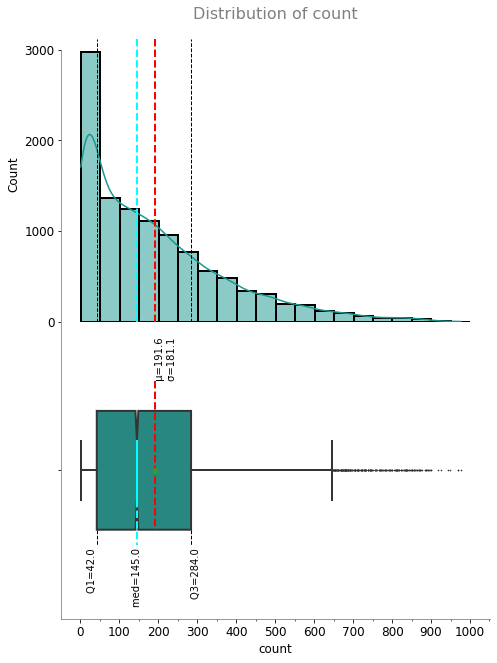

```python
plot_numeric_distribution(df, 'count', 'Tittle_', 'xlablel_', 'title_', box_major=100, box_minor=50)
```

Distribution is right skewed.

Add a new variable: log(count) and check its distribution.

```python
df['count_log'] = np.log(df['count'])
```

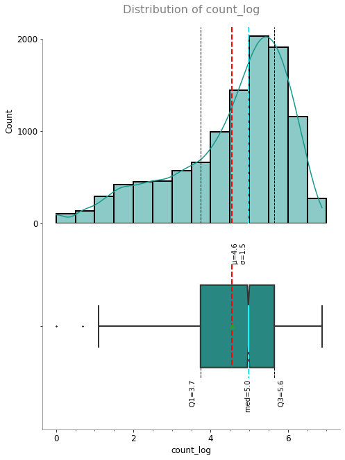

```python
plot_numeric_distribution(df, 'count_log', 'Tittle_', 'xlablel_', 'title_', box_major=2, box_minor=0.5)
```

The distribution is nearly log normal.

**Casual**

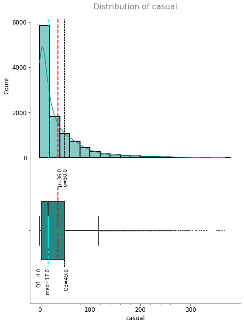

```python
plot_numeric_distribution(df, 'casual', 'Tittle_', 'xlablel_', 'title_', box_major=100, box_minor=20)
```

Distribution is right skewed.

Add a new variable: log(casual) and check its distribution.

```python
df['casual_log'] = np.log(df['casual'])
```

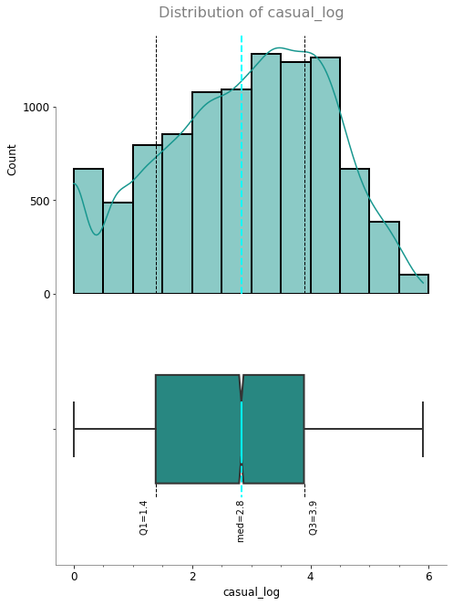

```python
plot_numeric_distribution(df, 'casual_log', 'Tittle_', 'xlablel_', 'title_', box_major=2, box_minor=0.5)
```

**Registered**

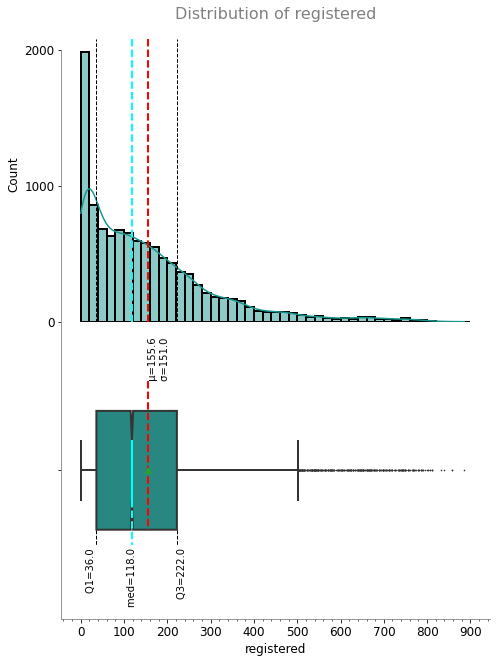

```python
plot_numeric_distribution(df, 'registered', 'Tittle_', 'xlablel_', 'title_', box_major=100, box_minor=20)
```

Distribution is right skewed.

Add a new variable: log(registered) and check its distribution.

```python
df['registered_log'] = np.log(df['registered'])
```

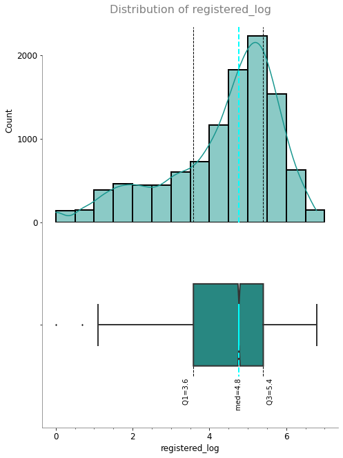

```python
plot_numeric_distribution(df, 'registered_log', 'Tittle_', 'xlablel_', 'title_', box_major=2, box_minor=0.5)
```

**Temperature**

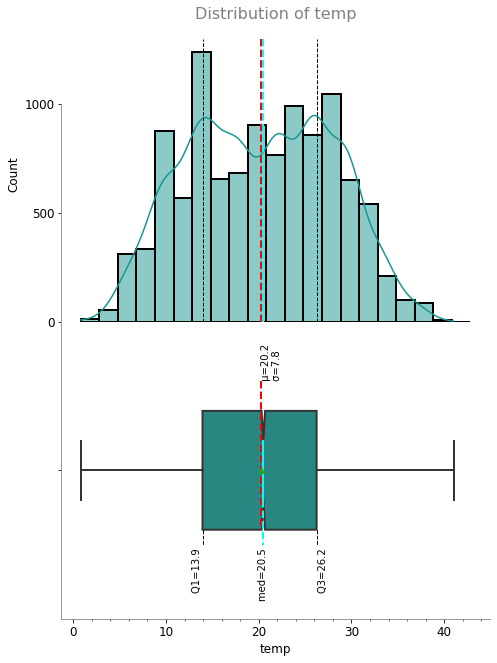

```python
plot_numeric_distribution(df, 'temp', 'Tittle_', 'xlablel_', 'title_', box_major=10, box_minor=2)
```

The distribution is bimodal.

**Feeling Temperature**

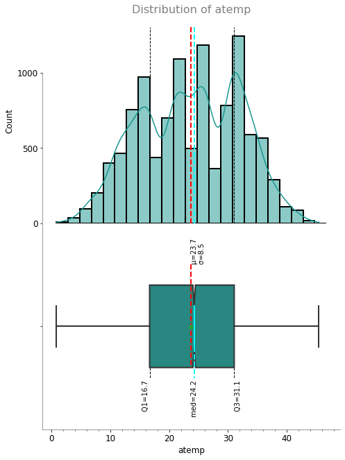

```python
plot_numeric_distribution(df, 'atemp', 'Tittle_', 'xlablel_', 'title_', box_major=10, box_minor=2)
```

The distribution is multi-modal.

**Humidity**

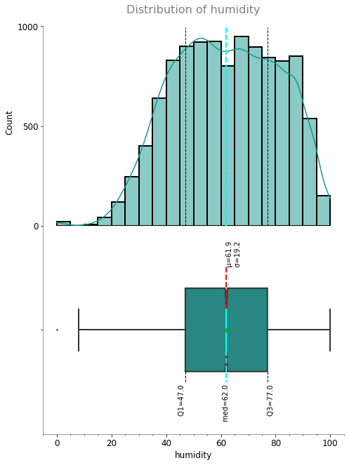

```python
plot_numeric_distribution(df, 'humidity', 'Tittle_', 'xlablel_', 'title_', box_major=20, box_minor=5)
```

The distribution is bimodal.

**Windspeed**

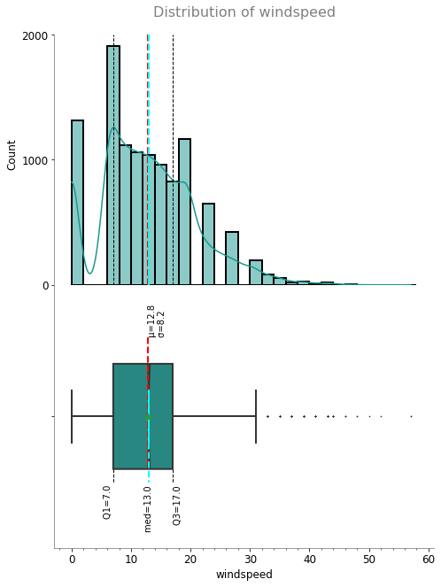

```python
plot_numeric_distribution(df, 'windspeed', 'Tittle_', 'xlablel_', 'title_', box_major=10, box_minor=2)
```

The distribution is bimodal.

**Season**

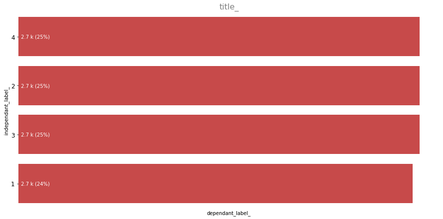

```python
plt_most10_count_plot(plt.subplot(), df, '', 'season', '', 'title_', 'independant_label_', 'dependant_label_', unit_='', highlight_num=None, highlight_color='#DC3535', orientation_='h', agg_func='Count', agg_var=None).show()
```

**Season wise Count**

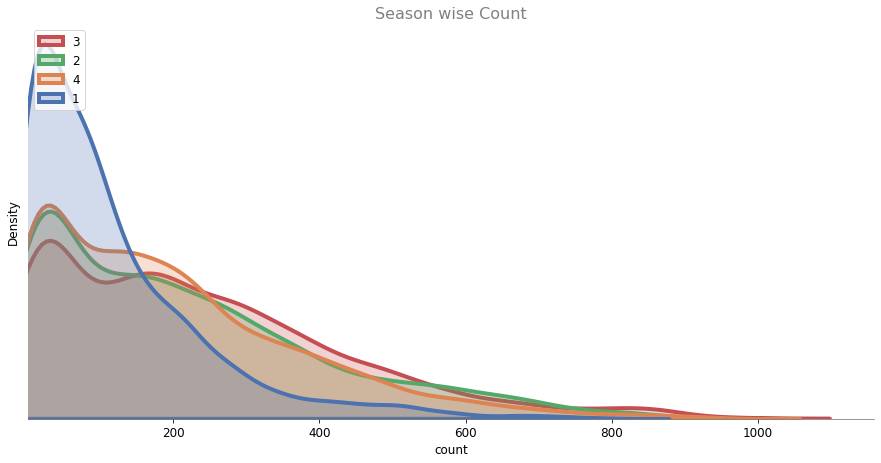

```python
plot_kde_distribution(plt.subplot(), df, 'season', 'count', 'Season wise Count', 'count', 'Density').show()
```

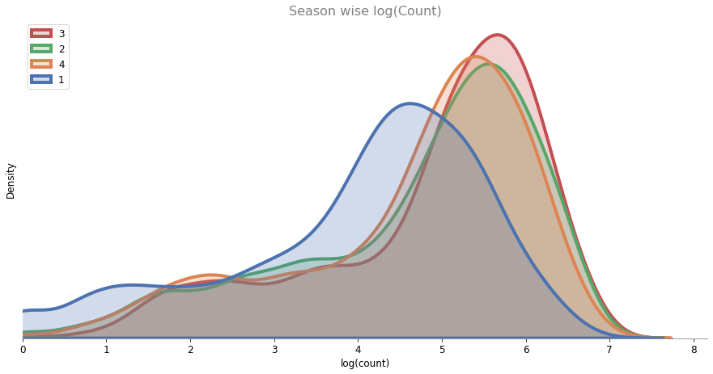

```python
plot_kde_distribution(plt.subplot(), df, 'season', 'count_log', 'Season wise log(Count)', 'log(count)', 'Density').show()
```

Log normal distribution for season 1 (spring) is apparently different from the other 3 (summer, fall, winter).

**Holiday**

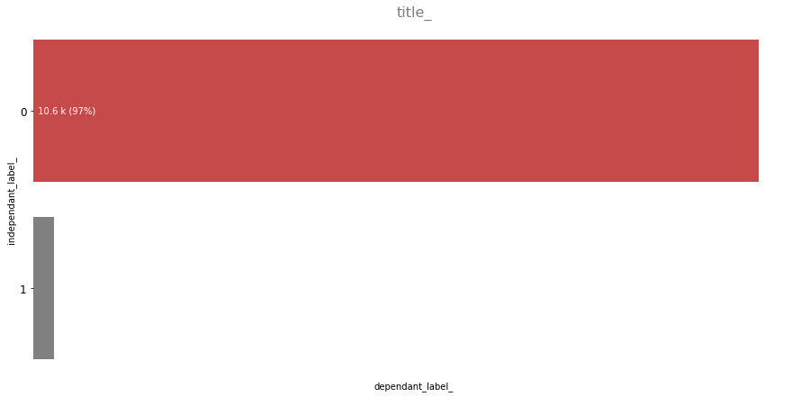

```python
plt_most10_count_plot(plt.subplot(), df, '', 'holiday', '', 'title_', 'independant_label_', 'dependant_label_', unit_='', highlight_num=None, highlight_color='#DC3535', orientation_='h', agg_func='Count', agg_var=None).show()
```

**Holiday vs log(Count)**

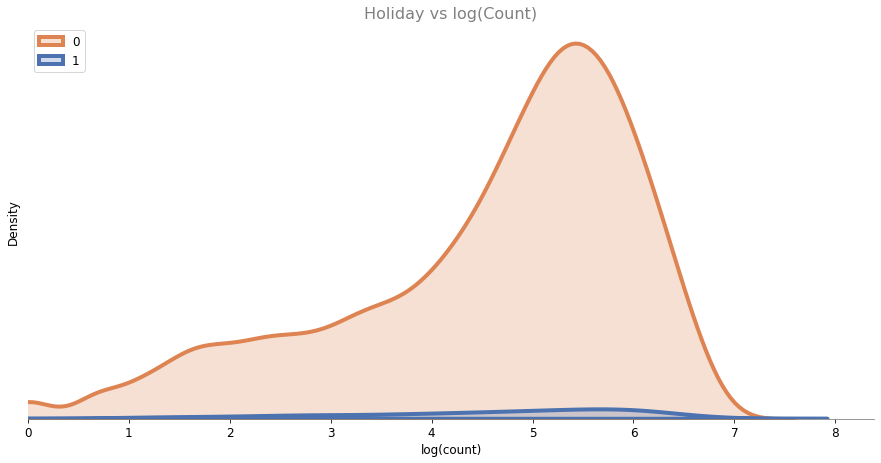

```python
plot_kde_distribution(plt.subplot(), df, 'holiday', 'count_log', 'Holiday vs log(Count)', 'log(count)', 'Density').show()
```

Log normal distributions for number of bikes rented on holidays or otherwise are apparently different.

**Working Day**

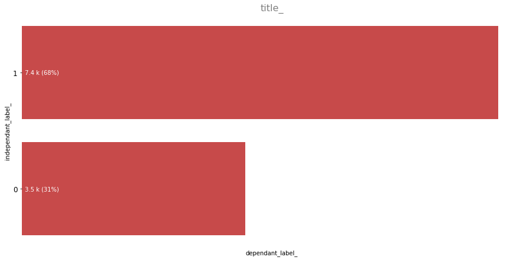

```python
plt_most10_count_plot(plt.subplot(), df, '', 'workingday', '', 'title_', 'independant_label_', 'dependant_label_', unit_='', highlight_num=None, highlight_color='#DC3535', orientation_='h', agg_func='Count', agg_var=None).show()
```

**Working Day vs log(Count)**

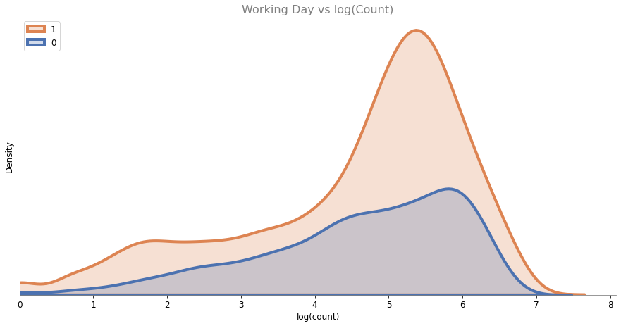

```python
plot_kde_distribution(plt.subplot(), df, 'workingday', 'count_log', 'Working Day vs log(Count)', 'log(count)', 'Density').show()
```

Log normal distributions for number of bikes rented on working days or otherwise are apparently different.

**Weather**

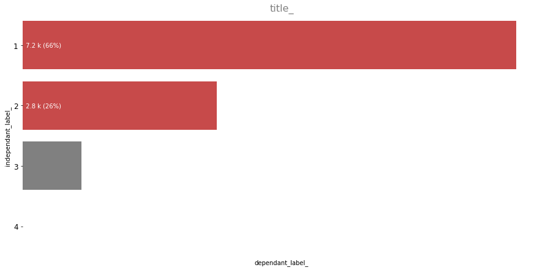

```python
plt_most10_count_plot(plt.subplot(), df, '', 'weather', '', 'title_', 'independant_label_', 'dependant_label_', unit_='', highlight_num=None, highlight_color='#DC3535', orientation_='h', agg_func='Count', agg_var=None).show()
```

**Weather vs log(Count)**

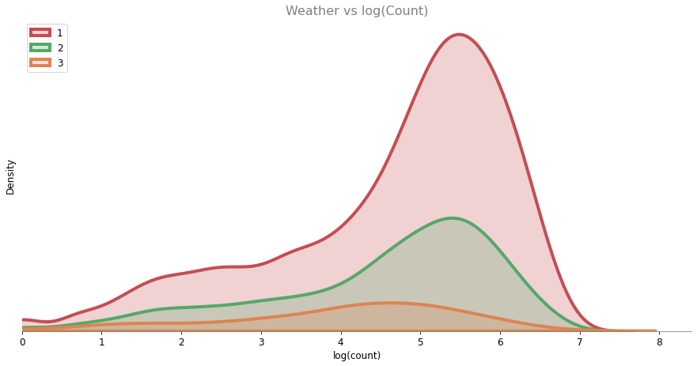

```python
plot_kde_distribution(plt.subplot(), df, 'weather', 'count_log', 'Weather vs log(Count)', 'log(count)', 'Density').show()
```

Log normal distributions for number of bikes rented during perticular weather condition is apparently different than other.

# Hypothesis Testing

## Test 1: Does number of bikes rented depend on whether it is a working day or not?

Null Hypothesis (Ho): Number of bikes rented does not depend on working day or not

Alternate Hypothesis (Ha): Number of bikes rented on working day are diffrent from that rented on non working day

Test: 2 sample t test, 2 tailed

```python
df1 = df.loc[df['workingday']==0, ['count_log']]
df2 = df.loc[df['workingday']==1, ['count_log']]
```

[output not shown]

```python
print('df1 var:', np.round(df1.var().count_log, 1))
print('df2 var:', np.round(df2.var().count_log, 1))
```

```
df1 var: 1.9
df2 var: 2.4
```

Variances are in acceptable limit (4:1). We can assume equal variance.

```python
stats.ttest_ind(a=df1, b=df2, equal_var=True)
```

```
Ttest_indResult(statistic=array([1.8913669]), pvalue=array([0.05860191]))
```

Since the p-value is greater than 0.05, we fail to reject the null hypothesis.

It shows that there is no significant evidence that the working day or otherwise have any effect on number of bikes rented.

## Test 2: Does number of bikes rented depend on season?

Null Hypothesis (Ho): Number of bikes rented does not depend on season

Alternate Hypothesis (Ha): Number of bikes rented on different seasons are not same

Test: ANOVA test

```python
df1 = df.loc[df['season']==1, ['count_log']]
df2 = df.loc[df['season']==2, ['count_log']]
df3 = df.loc[df['season']==3, ['count_log']]
df4 = df.loc[df['season']==4, ['count_log']]
```

```python
stats.f_oneway(df1, df2, df3, df4)
```

```
F_onewayResult(statistic=array([192.4476898]), pvalue=array([1.30713646e-121]))
```

It shows that there is significant evidence that the number of bikes rented are defferent for one season than the other.

## Test 3: Does number of bikes rented depend on weather?

Null Hypothesis (Ho): Number of bikes rented does not depend on weather

Alternate Hypothesis (Ha): Number of bikes rented on different weather condition are not same

Test: ANOVA test

```python
df1 = df.loc[df['weather']==1, ['count_log']]
df2 = df.loc[df['weather']==2, ['count_log']]
df3 = df.loc[df['weather']==3, ['count_log']]
df4 = df.loc[df['weather']==4, ['count_log']]
```

```python
stats.f_oneway(df1, df2, df3, df4)
```

```
F_onewayResult(statistic=array([49.87947148]), pvalue=array([5.21450012e-32]))
```

It shows that there is significant evidence that the number of bikes rented are defferent for different weather conditions.

## Test 4: Does weather conditions vary (or depend on) with the season?

Null Hypothesis (Ho): Weather conditions are independent of season

Alternate Hypothesis (Ha): Weather conditions depend on season

Test: chi-squared test

```python
df_table = pd.crosstab(df['season'], df['weather'])
df_table
```

| weather season | 1 | 2 | 3 | 4 |
| --- | --- | --- | --- | --- |
| 1 | 1759 | 715 | 211 | 1 |
| 2 | 1801 | 708 | 224 | 0 |
| 3 | 1930 | 604 | 199 | 0 |
| 4 | 1702 | 807 | 225 | 0 |

```python
chi_stat, p_value, degree_of_freedom, expected_values = stats.chi2_contingency(df_table)
print('chi_stat:', chi_stat)
print('p_value:', p_value)
```

```
chi_stat: 49.158655596893624
p_value: 1.549925073686492e-07
```

It shows that there is significant evidence that the weather conditions depend on season.

# Inference

- There is no significant evidence that the working day or otherwise have any effect on number of bikes rented.
- There is significant evidence that the number of bikes rented are defferent for one season than the other.
- There is significant evidence that the number of bikes rented are defferent for different weather conditions.
- There is significant evidence that the weather conditions depend on season.